# PCA StatQuest

# Principle Component Analysis

[Statquest Video](https://www.youtube.com/watch?v=0Jp4gsfOLMs&t=0s)

## Generate fake dataset

```r
data.matrix <- matrix(nrow = 100, ncol = 10)
colnames(data.matrix) <- c(paste("wt", 1:5, sep = ""),
                           paste("ko", 1:5, sep = ""))

rownames(data.matrix) <- paste("gene", 1:100, sep="")

head(data.matrix)
```

```
      wt1 wt2 wt3 wt4 wt5 ko1 ko2 ko3 ko4 ko5
gene1  NA  NA  NA  NA  NA  NA  NA  NA  NA  NA
gene2  NA  NA  NA  NA  NA  NA  NA  NA  NA  NA
gene3  NA  NA  NA  NA  NA  NA  NA  NA  NA  NA
gene4  NA  NA  NA  NA  NA  NA  NA  NA  NA  NA
gene5  NA  NA  NA  NA  NA  NA  NA  NA  NA  NA
gene6  NA  NA  NA  NA  NA  NA  NA  NA  NA  NA
```

```r
for (i in 1:100) {
  wt.values <- rpois(5, lambda = sample(x = 10:1000, size = 1))
  ko.values <- rpois(5, lambda = sample(x = 10:1000, size = 1))

  data.matrix[i,] <- c(wt.values, ko.values)
}

head(data.matrix)
```

```
      wt1 wt2 wt3 wt4 wt5 ko1  ko2 ko3 ko4  ko5
gene1 186 178 193 178 183 960 1029 969 954 1029
gene2 209 215 186 224 207 806  854 825 830  836
gene3 596 611 614 600 583 776  745 803 794  779
gene4 315 276 284 277 284 160  152 150 146  164
gene5  62  66  76  76  62 496  472 477 496  470
gene6 957 904 856 879 888 372  454 430 413  431
```

## `prcomp()`

Determine if the data is related prcomp expects genes to be columns and samples to be rows we need to transpose the matrix with `t()`

```r
pca <- prcomp(t(data.matrix), scale = TRUE)
```

**x** contains the principle components (PCs) for drawing a graph Here we use the first two columns in x to draw a 2-d plot of the first PCs

The first PC accounts for the most varation in the original data, the 2nd accounts for the 2nd most variation, etc. Typically the first 2 are used but sometimes P2 and P3 are used.

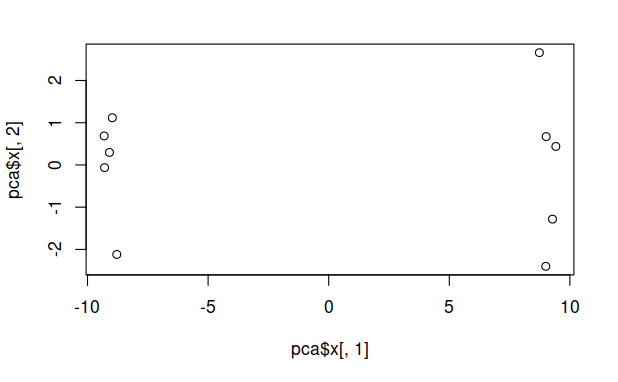

```r
plot(pca$x[,1], pca$x[,2])
```

To get a sense of how meaningful the clusters are we can see how much of the variation in the original is accounted for by PC1.

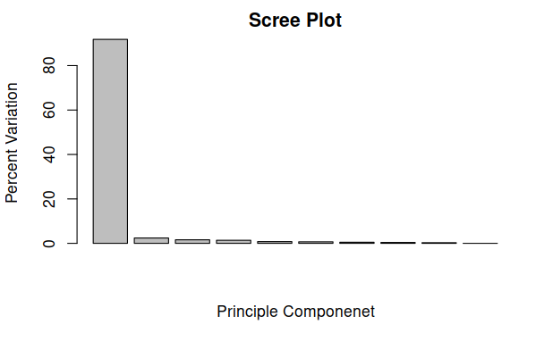

```r
pca.var <- pca$sdev^2
pca.var.per <- round(pca.var/sum(pca.var) * 100, 1)
barplot(pca.var.per, main = "Scree Plot",
        xlab = "Principle Componenet",
        ylab = "Percent Variation")
```

## `ggplot`

```r
library(ggplot2)
```

```r
pca.data <- data.frame(Sample = rownames(pca$x),
                       X = pca$x[,1],
                       Y = pca$x[,2])

head(pca.data)
```

|  | Sample | X | Y |
| --- | --- | --- | --- |
| wt1 | wt1 | -9.308893 | 0.68694369 |
| wt2 | wt2 | -8.970460 | 1.11713042 |
| wt3 | wt3 | -9.089066 | 0.29588566 |
| wt4 | wt4 | -8.785805 | -2.11977417 |
| wt5 | wt5 | -9.291810 | -0.06391076 |
| ko1 | ko1 | 9.016481 | 0.67162433 |

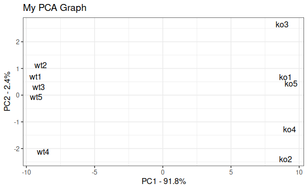

```r
ggplot(data = pca.data, aes(x=X, y=Y, label=Sample)) +
  geom_text() +
  xlab(paste("PC1 - ", pca.var.per[1], "%", sep = "")) +
  ylab(paste("PC2 - ", pca.var.per[2], "%", sep = "")) +
  theme_bw() +
  ggtitle("My PCA Graph")
```

## Loading scores

`prcomp()` creates loading scores called **rotation**

Since PC1 accounts for 92% of the variation we can look at the loading scores for PC1

```r
loading_scores <- pca$rotation[,1]
```

Genes that push samples to the left will have large negative values. Genes that push samples to the right will have large positive values Since we want order of magnitute we can use absolute values

```r
gene_scores <- abs(loading_scores)
gene_scores_ranked <- sort(gene_scores, decreasing = TRUE)
top_10_genes <- names(gene_scores_ranked[1:10])
top_10_genes
```

```
 [1] "gene75" "gene52" "gene92" "gene94" "gene50" "gene87" "gene2"
 [8] "gene5"  "gene57" "gene60"
```

Now check which had positive loading scores

```r
pca$rotation[top_10_genes,1]
```

```
    gene75     gene52     gene92     gene94     gene50     gene87
 0.1043023  0.1042916  0.1042789  0.1042696 -0.1042573 -0.1042437
     gene2      gene5     gene57     gene60
 0.1042396  0.1042376 -0.1042305 -0.1042264
```